# Microbiome data processing

Leo Lahti, Sudarshan Shetty et al.

**Processing phyloseq objects**

Instructions to manipulate microbiome data sets using tools from the [phyloseq package](http://joey711.github.io/phyloseq/) and some extensions from the [microbiome package](https://github.com/microbiome/microbiome), including subsetting, aggregating and filtering.

Load example data:

```r
library(phyloseq)
library(microbiome)
library(knitr)
data(atlas1006)
# Rename the example data (which is a phyloseq object)
pseq <- atlas1006
```

## Summarizing the contents of a phyloseq object

```r
summarize_phyloseq(pseq)
```

```
## Compositional = NO2
```

[output not shown]

```
## [[1]]
## [1] "1] Min. number of reads = 1900"
##
## [[2]]
## [1] "2] Max. number of reads = 28883"
##
## [[3]]
## [1] "3] Total number of reads = 13546564"
##
## [[4]]
## [1] "4] Average number of reads = 11769.3866203301"
##
## [[5]]
## [1] "5] Median number of reads = 11171"
##
## [[6]]
## [1] "7] Sparsity = 0.209002205440086"
##
## [[7]]
## [1] "6] Any OTU sum to 1 or less? NO"
##
## [[8]]
## [1] "8] Number of singletons = 0"
##
## [[9]]
## [1] "9] Percent of OTUs that are singletons \n        (i.e. exactly one read detected across all samples)0"
##
## [[10]]
## [1] "10] Number of sample variables are: 10"
##
## [[11]]
##  [1] "age"                   "sex"                   "nationality"           "DNA_extraction_method" "project"
##  [6] "diversity"             "bmi_group"             "subject"               "time"                  "sample"
```

## Retrieving data elements from phyloseq object

A phyloseq object contains OTU table (taxa abundances), sample metadata, taxonomy table (mapping between OTUs and higher-level taxonomic classifications), and phylogenetic tree (relations between the taxa). Some of these are optional.

Pick metadata as data.frame:

```r
meta <- meta(pseq)
```

Taxonomy table:

```r
taxonomy <- tax_table(pseq)
```

Abundances for taxonomic groups (‘OTU table’) as a TaxaxSamples matrix:

```r
# Absolute abundances
otu.absolute <- abundances(pseq)

# Relative abundances
otu.relative <- abundances(pseq, "compositional")
```

Total read counts:

```r
reads_sample <- readcount(pseq)
# check for first 5 samples
reads_sample[1:5]
```

```
## Sample-1 Sample-2 Sample-3 Sample-4 Sample-5
##     7593    10148     7131    10855    12000
```

Add read per sample to phyloseq object metadata.

```r
sample_data(pseq)$reads_sample <- reads_sample

# reads_sample is add to the last column in sample_data of pseq object.
head(meta(pseq)[,c("sample", "reads_sample")])
```

```
##            sample reads_sample
## Sample-1 Sample-1         7593
## Sample-2 Sample-2        10148
## Sample-3 Sample-3         7131
## Sample-4 Sample-4        10855
## Sample-5 Sample-5        12000
## Sample-6 Sample-6         7914
```

Melting phyloseq data for easier plotting:

```r
df <- psmelt(pseq)
kable(head(df))
```

|  | OTU | Sample | Abundance | age | sex | nationality | DNA_extraction_method | project | diversity | bmi_group | subject | time | sample | reads_sample | Phylum | Family | Genus |
| --- | --- | --- | --- | --- | --- | --- | --- | --- | --- | --- | --- | --- | --- | --- | --- | --- | --- |
| 110989 | Prevotella melaninogenica et rel. | Sample-448 | 14961 | 54 | female | CentralEurope | o | 18 | 5.98 | lean | 448 | 0 | Sample-448 | 26546 | Bacteroidetes | Bacteroidetes | Prevotella melaninogenica et rel. |
| 111380 | Prevotella melaninogenica et rel. | Sample-360 | 14296 | 45 | female | CentralEurope | o | 13 | 5.49 | severeobese | 360 | 0 | Sample-360 | 21086 | Bacteroidetes | Bacteroidetes | Prevotella melaninogenica et rel. |
| 111232 | Prevotella melaninogenica et rel. | Sample-190 | 13676 | 34 | female | CentralEurope | r | 7 | 6.06 | lean | 190 | 0 | Sample-190 | 23954 | Bacteroidetes | Bacteroidetes | Prevotella melaninogenica et rel. |
| 111553 | Prevotella melaninogenica et rel. | Sample-743 | 13509 | 52 | male | US | NA | 19 | 5.21 | obese | 743 | 0 | Sample-743 | 20632 | Bacteroidetes | Bacteroidetes | Prevotella melaninogenica et rel. |
| 110590 | Prevotella melaninogenica et rel. | Sample-366 | 13490 | 52 | female | CentralEurope | o | 15 | 5.63 | obese | 366 | 0 | Sample-366 | 19651 | Bacteroidetes | Bacteroidetes | Prevotella melaninogenica et rel. |
| 111029 | Prevotella melaninogenica et rel. | Sample-375 | 13384 | 45 | female | CentralEurope | o | 16 | 5.64 | severeobese | 375 | 0 | Sample-375 | 21408 | Bacteroidetes | Bacteroidetes | Prevotella melaninogenica et rel. |

## Sample operations

Sample names and variables

```r
head(sample_names(pseq))
```

```
## [1] "Sample-1" "Sample-2" "Sample-3" "Sample-4" "Sample-5" "Sample-6"
```

Total OTU abundance in each sample

```r
s <- sample_sums(pseq)
```

Abundance of a given species in each sample

```r
head(abundances(pseq)["Akkermansia",])
```

```
## Sample-1 Sample-2 Sample-3 Sample-4 Sample-5 Sample-6
##       21       36      475       61       34       14
```

Select a subset by metadata fields:

```r
pseq.subset <- subset_samples(pseq, nationality == "AFR")
```

Select a subset by providing sample names:

```r
# Check sample names for African Females in this phyloseq object
s <- rownames(subset(meta(pseq), nationality == "AFR" & sex == "Female"))

# Pick the phyloseq subset with these sample names
pseq.subset2 <- prune_samples(s, pseq)
```

Pick samples at the baseline time points only:

```r
pseq0 <- baseline(pseq)
```

## Data transformations

The microbiome package provides a wrapper for standard sample/OTU transforms. For arbitrary transforms, use the transform_sample_counts function in the phyloseq package. Log10 transform is log(1+x) if the data contains zeroes. Also “Z,” “clr,” “hellinger,” and “shift” are available as common transformations. Relative abundances (note that the input data needs to be in absolute scale, not logarithmic!):

```r
pseq.compositional <- microbiome::transform(pseq, "compositional")
```

```r
data(dietswap)
x <- dietswap
# Compositional data
x2 <- microbiome::transform(x, "compositional")
```

## Variable operations

Sample variable names

```r
sample_variables(pseq)
```

```
##  [1] "age"                   "sex"                   "nationality"           "DNA_extraction_method" "project"
##  [6] "diversity"             "bmi_group"             "subject"               "time"                  "sample"
## [11] "reads_sample"
```

Pick values for a given variable

```r
head(get_variable(pseq, sample_variables(pseq)[1]))
```

```
## [1] 28 24 52 22 25 42
```

Assign new fields to metadata

```r
# Calculate diversity for samples
div <- microbiome::alpha(pseq, index = "shannon")

# Assign the estimated diversity to sample metadata
sample_data(pseq)$diversity <- div
```

## Taxa operations

Number of taxa

```r
n <- ntaxa(pseq)
```

Most abundant taxa

```r
topx <- top_taxa(pseq, n = 10)
```

Names

```r
ranks <- rank_names(pseq)  # Taxonomic levels
taxa  <- taxa(pseq)        # Taxa names at the analysed level
```

Subset taxa

```r
pseq.bac <- subset_taxa(pseq, Phylum == "Bacteroidetes")
```

Prune (select) taxa:

```r
# List of Genera in the Bacteroideted Phylum
taxa <- map_levels(NULL, "Phylum", "Genus", pseq)$Bacteroidetes

# With given taxon names
ex2 <- prune_taxa(taxa, pseq)

# Taxa with positive sum across samples
ex3 <- prune_taxa(taxa_sums(pseq) > 0, pseq)
```

Filter by user-specified function values (here variance):

```r
f <- filter_taxa(pseq, function(x) var(x) > 1e-05, TRUE)
```

List unique phylum-level groups:

```r
head(get_taxa_unique(pseq, "Phylum"))
```

```
## [1] "Actinobacteria"  "Firmicutes"      "Proteobacteria"  "Verrucomicrobia" "Bacteroidetes"   "Spirochaetes"
```

Pick the taxa abundances for a given sample:

```r
samplename <- sample_names(pseq)[[1]]

# Pick abundances for a particular taxon
tax.abundances <- abundances(pseq)[, samplename]
```

## Get

```r
library(jeevanuDB)
```

```r
# Example data
data("moving_pictures")
# Rename
ps <- moving_pictures
taxa_names(ps)[1:2]
```

```
## [1] "TACGGAGGATACGAGCGTTATCCGGATTTATTGGGTTTAAAGGGTGCGTAGGTGGCTGATTAAGTCAGTGGTGAAAAGCTATGGCTCAACCATAGTCTTGCCGTTGATACTGGTTAGCTTGAGTGTAGATGATGTAGGCGGAATGCGTAG"
## [2] "TACAGAGGGTGCAAGCGTTAATCGGAATTACTGGGCGTAAAGCGAGCGTAGGTGGCTTGATAAGTCAGATGTGAAAGCCCCGGGCTTAACCTGGGAACGGCATCTGATACTGTTAGGCTAGAGTAGGTGAGAGGAAGGTAGAATTCCAGG"
```

The taxa names are unique sequences. This common when using `dada2` for denoising and identifying amplicon sequence variants.

```r
print(ps)
```

```
## phyloseq-class experiment-level object
## otu_table()   OTU Table:         [ 3644 taxa and 1966 samples ]
## sample_data() Sample Data:       [ 1966 samples by 89 sample variables ]
## tax_table()   Taxonomy Table:    [ 3644 taxa by 7 taxonomic ranks ]
```

It would be useful to store these inside the `refseq()` slot of phyloseq. For this we can use `microbiome::add_refseq`

```r
ps <- add_refseq(ps, tag = "ASV")
# check again
taxa_names(ps)[1:2]
```

```
## [1] "ASV1" "ASV2"
```

```r
print(ps)
```

```
## phyloseq-class experiment-level object
## otu_table()   OTU Table:         [ 3644 taxa and 1966 samples ]
## sample_data() Sample Data:       [ 1966 samples by 89 sample variables ]
## tax_table()   Taxonomy Table:    [ 3644 taxa by 7 taxonomic ranks ]
## refseq()      DNAStringSet:      [ 3644 reference sequences ]
```

As can be seen, the sequence ids are converted to ASV ids and sequences stored within the `refseq()` slot.

## Labelling ASVs with best taxonomy

Converting or amending the ASV ids with their best/lowest taxonomic classification can be very handy. This can be achieved with `microbiome::add_besthit()`

```r
ps <- add_besthit(ps)
taxa_names(ps)[1:2]
```

```
## [1] "ASV1:g__Porphyromonas.s__"         "ASV2:g__Psychrobacter.s__pulmonis"
```

If required, the names can be cleaned as follows.

```r
taxa_names(ps) <- gsub("[a-x]__", "",taxa_names(ps))
taxa_names(ps)[1:2]
```

```
## [1] "ASV1:Porphyromonas."         "ASV2:Psychrobacter.pulmonis"
```

## Merging operations

Aggregate taxa to higher taxonomic levels. This is particularly useful if the phylogenetic tree is missing. When it is available, see [merge_samples, merge_taxa and tax_glom](http://joey711.github.io/phyloseq/merge.html)).

```r
pseq2 <- aggregate_taxa(pseq, "Phylum")
```

Merge the desired taxa into “Other” category. Here, we merge all Bacteroides groups into a single group named Bacteroides.

```r
pseq2 <- merge_taxa2(pseq, pattern = "^Bacteroides", name = "Bacteroides")
```

Merging phyloseq objects with the phyloseq package:

```r
merge_phyloseq(pseqA, pseqB)
```

Joining otu/asv table and taxonomy in one data frame

```r
library(dplyr)
library(microbiome)
data("atlas1006") # example data from microbiome pkg
otu.tax.tibble <- combine_otu_tax(atlas1006, column.id = "ASVID")
# view first fist rows and columns
otu.tax.tibble[1:5,1:5]
```

```
## # A tibble: 5 x 5
##   ASVID                        Phylum          Family          Genus                        `Sample-1`
##   <chr>                        <chr>           <chr>           <chr>                             <dbl>
## 1 Actinomycetaceae             Actinobacteria  Actinobacteria  Actinomycetaceae                      0
## 2 Aerococcus                   Firmicutes      Bacilli         Aerococcus                            0
## 3 Aeromonas                    Proteobacteria  Proteobacteria  Aeromonas                             0
## 4 Akkermansia                  Verrucomicrobia Verrucomicrobia Akkermansia                          21
## 5 Alcaligenes faecalis et rel. Proteobacteria  Proteobacteria  Alcaligenes faecalis et rel.          1
```

## Get tibbles

In many cases, user may want to extract slots from phyloseq as tibbles for custom data processing.  
This can be achieved with following functions.

```r
otu.tib <- otu_tibble(atlas1006, column.id = "FeatureID")

tax.tib <- tax_tibble(atlas1006, column.id = "FeatureID")

sample.tib <- sample_tibble(atlas1006, column.id = "SampleID")
```

## Convert to tidy long format

As an alternative to `phyloseq::psmelt`, we provide `psmelt2` which returns a tibble in long format.

```r
ps.long.tib <- psmelt2(pseq)
head(ps.long.tib)
```

```
## # A tibble: 6 x 17
##   FeatureID  .SampleID value Phylum  Family  Genus    age sex   nationality DNA_extraction_~ project diversity$diver~ bmi_group subject
##   <chr>      <chr>     <dbl> <chr>   <chr>   <chr>  <int> <fct> <fct>       <fct>            <fct>              <dbl> <fct>     <fct>
## 1 Actinomyc~ Sample-1      0 Actino~ Actino~ Actin~    28 male  US          <NA>             1                   3.19 severeob~ 1
## 2 Actinomyc~ Sample-2      0 Actino~ Actino~ Actin~    24 fema~ US          <NA>             1                   3.39 obese     2
## 3 Actinomyc~ Sample-3      0 Actino~ Actino~ Actin~    52 male  US          <NA>             1                   2.86 lean      3
## 4 Actinomyc~ Sample-4      0 Actino~ Actino~ Actin~    22 fema~ US          <NA>             1                   3.06 underwei~ 4
## 5 Actinomyc~ Sample-5      0 Actino~ Actino~ Actin~    25 fema~ US          <NA>             1                   3.07 lean      5
## 6 Actinomyc~ Sample-6      0 Actino~ Actino~ Actin~    42 male  US          <NA>             1                   2.94 lean      6
## # ... with 3 more variables: time <dbl>, sample <chr>, reads_sample <dbl>
```

## Rarefaction

```r
pseq.rarified <- rarefy_even_depth(pseq)
```

## Taxonomy

Convert between taxonomic levels (here from Genus (Akkermansia) to Phylum (Verrucomicrobia):

```r
m <- map_levels("Akkermansia", "Genus", "Phylum", tax_table(pseq))
print(m)
```

```
## [1] "Verrucomicrobia"
```

## Metadata

Visualize frequencies of given factor (sex) levels within the indicated groups (group):

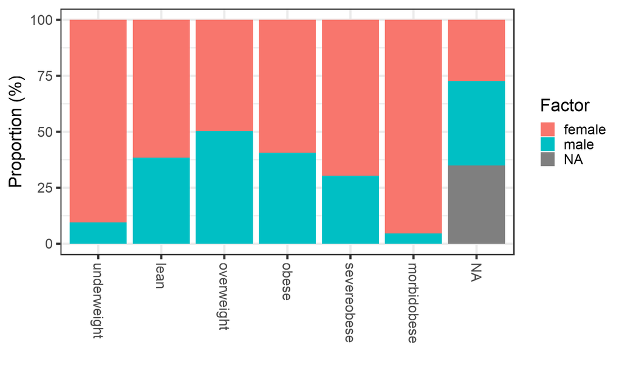

```r
p <- plot_frequencies(sample_data(pseq), "bmi_group", "sex")
print(p)
```

```r
# Retrieving the actual data values:
# kable(head(p@data), digits = 2)
```

Custom functions are provided to cut age or BMI information into discrete classes.

```r
group_bmi(c(22, 28, 31), "standard")
```

```
## [1] lean       overweight obese
## Levels: underweight lean overweight obese severe morbid super
```

```r
group_age(c(17, 41, 102), "decades")
```

```
## [1] [10,20)   [40,50)   [100,110]
## Levels: [10,20) [20,30) [30,40) [40,50) [50,60) [60,70) [70,80) [80,90) [90,100) [100,110]
```

Add metadata to a phyloseq object. For reproducibility, we just use the existing metadata in this example, but this can be replaced by another data.frame (samples x fields).

```r
# Example data
data(dietswap)
pseq <- dietswap

# Pick the existing metadata from a phyloseq object
# (or retrieve this from another source)
df <- meta(pseq)

# Merge the metadata back in the phyloseq object
pseq2 <- merge_phyloseq(pseq, sample_data(df))
```